# Early gigantic lamniform marks the onset of large-body size in modern shark evolution

Supplementary Data:

Stanford Doer School of Sustainability, Paleobiology Lab

Author

Affiliation

[Mohamad Bazzi](https://github.com/mohabazzi)

[Stanford University](https://sustainability.stanford.edu/)

Published

2025-06-16

```css
.sidebar nav {
  position: sticky;
  top: 80px;
}
```

## Article summary

Lamniform sharks include some of the largest-bodied organisms on Earth and trace their origin back ~135 million years. A growing, although exiguous archive of fossilized remains from the nascent stages of lamniform shark evolution indicates that large body sizes evolved long before lamniform species replaced marine tetrapods as top predators during the early half of the Late Cretaceous. The evolution of large body size in sharks has been linked with both physiological and environmental adaptations, in particular endothermy, and the ecological expansion into oceanic waters. Here, we report the oldest known giant lamniform shark, diagnosed from isolated vertebral centra and discovered in a ~115-million-year-old inner-neritic deposit (Aptian, Early Cretaceous) from Darwin, Northern Territory, Australia. Using a comprehensive dataset of living lamniform sharks comprising 1,912 individuals, we built and fitted both intra-and interspecific regression models based on the relationship between vertebral centrum diameter and total length. These models were applied to predict the body size of this new giant shark alongside other Cretaceous lamniform species known from vertebral elements. Our main results demonstrate that giant body sizes (≥ 6 meters) in lamniform sharks have an ancient origin, with our new fossil discovery supporting a neritic hypothesis for the evolutionary emergence of such phenotypic trait. Furthermore, notwithstanding the challenge in reconstructing the trophic ecology of extinct species, our new size estimates underscore a continuity and diversity of large body sizes throughout lamniform evolutionary history.

## Libraries

```r
R.packages <- c("ozmaps ggspatial dplyr openxlsx ggplot2 tidyr reshape janitor downlit sf see
                 purrr readxl kableExtra knitr gtsummary gt MASS broom emmeans geomorph xml2 broom.helpers
                 smatr MASSTIMATE ggpmisc ggrepel smatr performance flextable Metrics magick
                 rempsyc car forcats RRPP caper geiger phangorn lmtest
                 MuMIn phytools conflicted tibble irr nlme ggdist adephylo ggpubr patchwork")

import_packages <-
  function(x)
  x |> trimws() |> strsplit("\\s+") |> unlist() |>
  lapply(function(x) library(x, character.only = T)) |>
  suppressMessages() |>
  suppressWarnings()

R.packages |> import_packages()

# Resolve conflicted functions.
conflicted::conflict_prefer("map", "purrr")
conflicted::conflict_prefer("filter", "dplyr")
conflicted::conflict_prefer("select", "dplyr")
conflicted::conflict_prefer("rename","dplyr")
conflicted::conflict_prefer("summarize", "dplyr")
conflicted::conflict_prefer("annotate", "ggplot2")
conflicted::conflict_prefer("AICc", "MuMIn")
```

## Custom functions

```r
#' @title Compute average measurements across multiple dataframes
#'
#' @description #' This function takes a list of data frames and a set of variable names, and returns a single data frame containing the average values of those
#' variables across all input data frames.
#'
#' @return A dataframe.
#' @details Remove is given as an argument to filter the 'replicate column' which is numeric and losses meaning after Reduce is applied.

aggregate_measurements <- function(path = NULL, remove = NULL) {
  sheets <- getSheetNames(file = path)
  numeric_var <- lapply(sheets, function(x) {
    df <- read.xlsx(xlsxFile = path, sheet = x)
    df |> select(where(is.numeric))
  })
  names(numeric_var) <- sheets
  # Compute the average.
  ave_sum <- Reduce(f = "+",x = numeric_var)/length(numeric_var)
  if (!is.null(remove)) {
    ave_sum <- ave_sum |> select(-all_of(remove))
  }
  return(ave_sum)
}

other_details <- function(path = NULL) {
  frame <-
    read.xlsx(xlsxFile = path, sheet = 1) |>
    # Bring back species and sex information.
    select(where(~ !is.numeric(.)))
    return(frame)
}

#' @title Intraclass correlation coefficient
#' @description
#' @return
#' @details

icc_custom <- function(path = NULL) {
  sheet_names <- getSheetNames(path)
  # List.
  sheet_lists <-
    map(sheet_names, ~ read.xlsx(path, sheet = .x))
  # Select variable.
  sheet_lists <-
    map(sheet_lists, ~ .x |> select("centrum_diameter_cm","total_length_cm")) |>
    lapply(as.data.frame)
  # Combine into master object.
  combined <- do.call(cbind,sheet_lists)

  names(combined) <- make.unique(names(combined))

  centrum <- combined |> select(matches("^centrum"))
  length  <- combined |> select(matches("length"))

  ls_obj  <- list(centrum,length)
  names(ls_obj) <- c("Centrum","Length")
  # Compute ICC.
  irr_centrum <- irr::icc(ratings = ls_obj$Centrum)
  irr_length  <- irr::icc(ratings = ls_obj$Length)

  irr_centrum_res <-
    cbind(irr_centrum$subjects,irr_centrum$raters,
          irr_centrum$value,irr_centrum$r0,
          irr_centrum$p.value) |>
  as.data.frame() |>
  setNames(nm = c("subjects","raters","value","r0","p-value"))

  irr_length_res <-
    cbind(irr_length$subjects,irr_length$raters,
          irr_length$value,irr_length$r0,
          irr_length$p.value) |>
  round(digits = 1) |>
  as.data.frame() |>
  setNames(nm = c("subjects","raters","value","r0","p-value"))

  # Combine results.
  combin_res <-
    bind_rows(irr_centrum_res,irr_length_res) |>
    mutate(variable = c("Centrum","Total Length"))

  return(combin_res)
}

#'@title Confidence and Prediction Intervals.

intervals <-  function(xvar,alpha=0.975) {
  mean<-mean(xvar)
  std<-sd(xvar)
  n<-length(xvar)
  ci.s.x<-sqrt((std^2)/n)
  pi.s.x<-std*sqrt(1+1/n)
  t<-qt(alpha,df=n-1)
  ci.uci<-mean+t*ci.s.x
  ci.lci<-mean-t*ci.s.x
  pi.uci<-mean+t*pi.s.x
  pi.lci<-mean-t*pi.s.x
  res<-as.list(c(round(mean,4),round(std,4),n,round(t,4),round(ci.lci,4),round(ci.uci,4),round(pi.lci,4),round(pi.uci,4)))
  names(res)<-c('mean','st.dev','N','t.stat','Lower.CI','Upper.CI','Lower.PI','Upper.PI')
  return(res)
}
```

## Aims

Here we adopt an extant-scaling approach using Ordinary Least Squares regression (OLS) modelling based on the total length (TL) and centrum diameter (CD) of modern lamniform species to **1)** explore the performance of centrum diameter as a proxy of body size; and **2)** generate body size predictions (total length and mass) in the hitherto largest described and geologically oldest giant lamniform shark on record.

## Fossil site

Geographic map of Casuarina Beach, Darwin, Northern Territory, Australia. The fossil locality is indicated by a red rectangle. The maps were generated programmatically using the ozmap and ggplot2 packages.

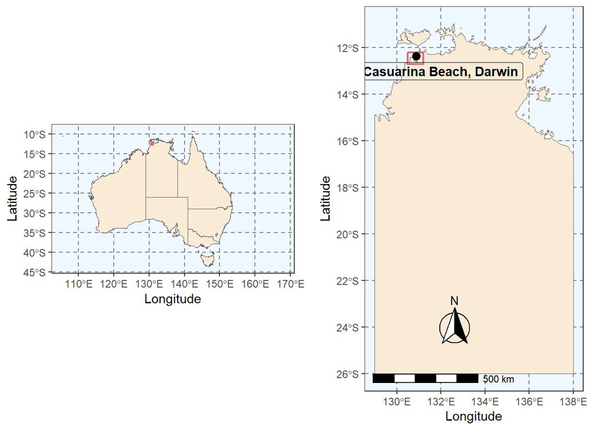

```r
AuMap <-
  ggplot(data = AU) +
  geom_sf(fill= "antiquewhite") +#
  annotate(geom = "rect",xmin = 130.5, xmax = 131.2, ymin = -12.7, ymax = -12.2, color = "#E16A86", fill = NA, lwd = .8) +
  xlab("Longitude") +
  ylab("Latitude") +
  theme_bw() +
  theme(panel.grid.major = element_line(color = gray(.5), linetype = "dashed", linewidth = 0.5),
        panel.background = element_rect(fill = "aliceblue"))

# Casuarina Beach, Darwin, Northern Territory.
ggarrange(AuMap,
          AU |>
  filter(NAME == "Northern Territory") |>
  ggplot(aes(fill = NAME)) +
  geom_sf(fill = "antiquewhite",show.legend = F) +
  labs(x= "Longitude", y = "Latitude") +
  # Darwin.
  geom_rect(aes(xmin = 130.5, xmax = 131.2, ymin = -12.7, ymax = -12.2), color = "#E16A86", fill = NA, lwd = .8) +
  # Casuarina Beach
  geom_point(aes(x = 130.873794555, y = -12.352499961), color = "black", size = 3,show.legend = F) +
  geom_label(aes(x = 132, y = -13, label = "Casuarina Beach, Darwin"),color = "black", fontface = 2, fill = NA) +
  annotation_scale(location = "bl", width_hint = 0.5) +
  annotation_north_arrow(location = "bl", which_north = "true", pad_x = unit(0.75, "in"), pad_y = unit(0.5, "in"),
                         style = north_arrow_fancy_orienteering) +
  theme_bw() +
  theme(plot.title = element_text(face = "bold"),
        panel.grid.major = element_line(color = gray(.5), linetype = "dashed", linewidth = 0.5),
        panel.background = element_rect(fill = "aliceblue")))
```

## Data sources

### Data wrangling and feature engineering

**Extant size data:** **[1]** Data on body length and mass, along with measurements of vertebral centra of white sharks (*Carcharodon carcharias*) off the east coast of South Africa (Wintner and Cliff 1998). **[2]** Equivalent measurement data compiled from the literature of Lamnidae and Alopiidae species: *Isurus oxyrinchus*, *Lamna nasus*, and *Alopias pelagicus* (Natanson et al. 2002; Natanson, Mello, and Campana 2002; Drew et al. 2015). **[3]** Complementary data extracted from static images of scatter plots showing the relationship between centrum diameter/radius and body length (fork, precaudal, and total length) of *Pseudocarcharias kamoharai* (Kindong et al. 1998), *Cetorhinus maximus* (Natanson et al. 2008), *Lamna ditropis* (Goldman and Musick 2006), *Carcharias taurus* (Lucifora 2003), *A. pelagicus* (Liu et al. 1999), *C. carcharias* (Cailliet et al. 1985), *A. vulpinus* (Cailliet et al. 1983), and *A. superciliosus* (Liu, Chiang, and Chen 1998). **[4]** Single specimen measurements of *Odontaspis noronhai* (Stone and Shimada 2019) and *O. ferox* (Hansen et al. 2013). **[5]** Vertebral centrum measurements, body size, sex, and vertebral count along the spinal column of captured *C. carcharias*, *L. nasus*, *I. oxyrinchus*, and *A. vulpinus* (Natanson et al. 1998).

**Fossil size data:** Literature-sourced data on body length and maximum vertebral centra from multiple Cretaceous lamniform species.

**Input data:** Five Aptian-aged cardabiodontid shark vertebral centra of unknown body size.

```r
# Alopias pelagicus (references: Liu et al. 1999, fig.1 and Drew et al. 2015).
alopias_pelagicus_liu <-
  cbind(
    aggregate_measurements(path = "data/Liu et al. 1999.xlsx",remove = "replicate"),
    other_details(path = "data/Liu et al. 1999.xlsx")
  ) |>
  relocate("species",.before = 1)

alopias_pelagicus_drew <-
  cbind(
    aggregate_measurements(path = "data/Drew et al. 2015.xlsx"),
    other_details(path = "data/Drew et al. 2015.xlsx")
  ) |>
  relocate(c("order","family","genus","species"),.before = 1)

# Combine the two sources.
alopias_pelagicus_data <-
  bind_rows(
    alopias_pelagicus_liu |>
      select(any_of(c("order","family","genus","species","centrum_diameter_cm","total_length_cm","reference"))),
    alopias_pelagicus_drew |>
      select(any_of(c("order","family","genus","species","centrum_diameter_cm","total_length_cm","reference")))
  )

# Alopias superciliosus (reference: Liu et al. 1998).
alopias_superciliosus_data <-
  cbind(
  aggregate_measurements(path = "data/Liu et al. 1998.xlsx",remove = "replicate"),
  other_details(path = "data/Liu et al. 1998.xlsx")
  ) |>
  relocate(c("order","family","genus","species"),.before = 1) |>
  select(!any_of(c("centrum_radius_mm","centrum_diameter_mm","specimen","total_length_mm","precaudal_length_cm","sex")))

# Alopias vulpinus (reference: Cailliet et al. 1983)
alopias_vulpinus_data <-
  cbind(
    aggregate_measurements(path = "data/Cailliet et al. 1983.xlsx",remove = "replicate"),
    other_details(path = "data/Cailliet et al. 1983.xlsx")
  ) |>
  relocate(c("order","family","genus","species"),.before = 1) |>
  select(!any_of(c("centrum_diameter_mm","specimen","total_length_mm")))

# Carcharias taurus (reference: Lucifora 2003, fig. 6.2)
carcharias_taurus_data <-
  cbind(
    aggregate_measurements(path = "data/Lucifora 2003.xlsx",remove = "replicate"),
    other_details(path = "data/Lucifora 2003.xlsx")
  ) |>
  relocate(c("order","family","genus","species"),.before = 1) |>
  select(!any_of(c("centrum_radius_mm","centrum_diameter_mm","specimen")))

# Carcharodon carcharias (reference: Cailliet et al. 1985, fig. 3, and Wintner and Cliff 1999, fig. 3)
carcharodon_carcharias_cailliet <-
  cbind(
    aggregate_measurements(path = "data/Cailliet et al. 1985.xlsx",remove = "replicate"),
    other_details(path = "data/Cailliet et al. 1985.xlsx")
  ) |>
  relocate(c("order","family","genus","species"),.before = 1) |>
  select(!any_of(c("centrum_radius_mm","centrum_diameter_mm","total_length_mm")))

carcharodon_carcharias_wintner <-
  cbind(
    aggregate_measurements(path = "data/Wintner & Cliff 1999.xlsx"),
    other_details(path = "data/Wintner & Cliff 1999.xlsx")
  ) |>
  relocate(c("order","family","genus","species"),.before = 1) |>
  select(!any_of(c("LAB","CAPDATE","CDPRED","TL_Measured"))) |>
  rename("precaudal_length_cm" = "PCL(cm)",
         "centrum_diameter_cm" = "CD(cm)",
         "Tagno" = "TAGNO",
         "netmass_kg" = "NETMASS",
         "sex" = "Sex") |>
  mutate(sex = ifelse(sex == 1,"male","female")) |>
  mutate_if(is.character,as.factor) |>
  mutate(sex = relevel(sex,"male")) |>
  # Converting-factor to TL (Total Length)
  mutate(total_length_cm = 1.251 * precaudal_length_cm + 5.207) |>
  mutate(log_tl = log10(total_length_cm),
         log_cd = log10(centrum_diameter_cm),
         log_netmass = log10(netmass_kg)) |>
  # Reshuffle column order.
  relocate("total_length_cm",.after = "netmass_kg") |>
  # Remove row with missing values in key variables.
  filter(!is.na(netmass_kg))

# Cetorhinus maximus (reference: Natanson et al. 2008, sample size = 21)
cetorhinus_maximus_data <-
  cbind(
    aggregate_measurements(path = "data/Natanson et al. 2008.xlsx",remove = "replicate"),
    other_details(path = "data/Natanson et al. 2008.xlsx")
  ) |>
  relocate(c("order","family","genus","species"),.before = 1)

# Lamna nasus (reference: Natanson et al. 2002, sample size = 575)
lamna_nasus_data <-
  cbind(
    aggregate_measurements(path = "data/Natanson et al. 2002.xlsx"),
    other_details(path = "data/Natanson et al. 2002.xlsx")
  ) |>
  relocate(c("order","family","genus","species"),.before = 1) |>
  relocate("centrum_diameter_cm",.before = "total_length_cm") |>
  select(!any_of(c("sample_number","number_of_band","centrum_radius_mm","fork_length_cm","centrum_diameter_mm","sex")))

# Lamna dipturs (reference: Goldman & Musick 2006, fig.2)
lamna_dipturs_data <-
  cbind(
    aggregate_measurements(path = "data/Goldman & Musick 2006.xlsx",remove = "replicate"),
    other_details(path = "data/Goldman & Musick 2006.xlsx")
  ) |>
  relocate(c("order","family","genus","species"),.before = 1) |>
  select(!any_of(c("centrum_radius_mm","centrum_diameter_mm","precaudal_length_cm")))

# Isurus oxyrinchus (reference:Natanson et al. 2006)
isurus_oxyrinchus_data <-
  cbind(
    aggregate_measurements(path = "data/Natanson et al. 2006.xlsx"),
    other_details(path = "data/Natanson et al. 2006.xlsx")
  ) |>
  relocate(c("order","family","genus","species"),.before = 1) |>
  relocate("centrum_diameter_cm",.before = "total_length_cm") |>
  select(!any_of(c("A","vetebral_radius_mm","fork_length_cm","centrum_diameter_mm","sex")))

# Pseudocarcharias kamoharai (reference: Kindong et al. 2020)
pseudocarcharias_kamoharai_data <-
  cbind(
    aggregate_measurements(path = "data/Kindong et al. 2020.xlsx",remove = "replicate"),
    other_details(path = "data/Kindong et al. 2020.xlsx")
  ) |>
  relocate(c("order","family","genus","species"),.before = 1) |>
  select(!any_of(c("centrum_radius_mm","fork_length_cm","centrum_diameter_mm")))
```

```r
# Lamniformes.
lamniformes_data <-
  bind_rows(
  alopias_pelagicus_data,
  alopias_superciliosus_data,
  alopias_vulpinus_data,
  carcharias_taurus_data,
  carcharodon_carcharias_cailliet,
  carcharodon_carcharias_wintner |> select("order","family","genus","species","centrum_diameter_cm","total_length_cm","reference"),
  cetorhinus_maximus_data,
  lamna_nasus_data,
  lamna_dipturs_data,
  isurus_oxyrinchus_data,
  pseudocarcharias_kamoharai_data
) |>
  mutate(log_tl = log10(total_length_cm),
         log_cd = log10(centrum_diameter_cm)
         ) |>
  mutate(species = as.factor(species))

# Alopiidae species measurement data.
alopiidae_data <-
  bind_rows(
  alopias_pelagicus_data,
  alopias_superciliosus_data,
  alopias_vulpinus_data) |>
  # Log-10 transform variables.
  mutate(log_cd  = log10(centrum_diameter_cm),log_tl = log10(total_length_cm)) |>
  relocate("reference",.after = 9) # N = 622.

# Combine all extant Lamnidae species.
lamnidae_data <-
  lamniformes_data |>
  filter(family == "Lamnidae")

# Complete White shark dataset.
carcharodon_carcharias_complete <-
  lamnidae_data |>
  filter(species == "Carcharodon carcharias")
```

```r
# Stem-lamniform dataset.
mesozoic_data <- openxlsx::read.xlsx(xlsxFile = "data/mesozoic_data.xlsx",sheet = 1)

# Natanson et al. 2018: white shark data.
Natanson <- "data/Natanson et al. 2018.xlsx"

natanson_data <-
  excel_sheets(path = Natanson) |>
  set_names() |>
  map(read_excel, path = Natanson)

# Complementary data from Natanson et al. 2018 (non-white shark data)
natanson_supplementary <- read.xlsx(xlsxFile = "data/Natanson et al. 2018_Supplementary.xlsx")
```

```r
# Table 1.
lamniformes_data |>
  group_by(species) |>
  # Compute TL range per species.
  summarise("Size Range (cm)" = paste0(round(min(total_length_cm),0), "-", round(max(total_length_cm),0)),
            "Reference" = dplyr::first(reference),
            "N" = n()) |>
  rename("Species" = "species") |>
  kable(caption = "Extant taxon sampling. Measurements from 10 lamniform species were sourced. Size-ranges are based on the total length
                   of each species sample (not to be confused with true minimum and maximum body sizes).") |>
  column_spec(column = 1,italic = T) |>
  kable_styling(bootstrap_options = "striped",
                            full_width = F)
```

Extant taxon sampling. Measurements from 10 lamniform species were sourced. Size-ranges are based on the total length of each species sample (not to be confused with true minimum and maximum body sizes).

| Species | Size Range (cm) | Reference | N |
| --- | --- | --- | --- |
| Alopias pelagicus | 140-361 | Liu et al. 1999 | 329 |
| Alopias superciliosus | 185-396 | Liu et al. 1998 | 226 |
| Alopias vulpinus | 165-565 | Cailliet et al. 1983 | 67 |
| Carcharias taurus | 201-267 | Lucifora 2003 | 76 |
| Carcharodon carcharias | 129-505 | Cailliet et al. 1985 | 129 |
| Cetorhinus maximus | 257-837 | Natanson et al. 2008 | 21 |
| Isurus oxyrinchus | 71-366 | Natanson et al. 2006 | 236 |
| Lamna ditropis | 87-260 | Goldman & Musick 2006 | 143 |
| Lamna nasus | 93-295 | Natanson et al. 2002 | 575 |
| Pseudocarcharias kamoharai | 62-116 | Kindong et al. 2020 | 110 |

```r
# Table 2.
mesozoic_data |>
  relocate(c(species,label), .before = centrum_diameter) |>
  relocate(c(reference),.after = estimated) |>
  kable(caption = "Fossil taxon sampling. Measurement data compiled from the literature of 15 lamniform shark species from the Cretaceous period.") |>
  column_spec(column = 1,italic = c(rep(TRUE,3),FALSE,rep(TRUE,2),FALSE,rep(TRUE,8))) |>
  kable_styling(bootstrap_options = "striped",
                            full_width = F)
```

Fossil taxon sampling. Measurement data compiled from the literature of 15 lamniform shark species from the Cretaceous period.

| species | label | centrum_diameter | total_length | family | unit | age | period | locality | comment | estimated | reference |
| --- | --- | --- | --- | --- | --- | --- | --- | --- | --- | --- | --- |
| Cretodus sp | IGVR 91032 | 115.0 | 6610 | non-Anacoracidae | mm | middle Turonian | Middle Cretaceous | Sant'Anna D'Alfaedo (Verona) | NA | yes | Amalfitano et al. 2017a |
| Cretoxyrhina mantelli | FHSM VP-2187 | 87.0 | 5000 | non-Anacoracidae | mm | late Coniacian–middle Santonian | Middle Cretaceous | Niobrara Chalk, Kansas | Estimated at 532 cm by Newbrey et al. 2015 | yes | Shimada 1997c |
| Cretalamna hattini | LACM 128126 | 40.0 | 2300 | non-Anacoracidae | mm | late Santonian-early Campanian | Late Cretaceous | upper Smoky Hill Chalk, Niobrara Formation, Logan County, Kansas | Midtrunk centra; Initially described as C. appendiculata | yes | Shimada 2007; Siversson et al. 2015 |
| Lamniform sp. | OMNH 68860 | 110.0 | 6300 | non-Anacoracidae | mm | Albian | Early Cretaceous | Texas | NA | yes | Frederickson et al. 2015 |
| Cretoxyrhina mantelli | MPPSA-IGVR 36371 | 107.0 | 6150 | non-Anacoracidae | mm | Turonian-Coniacian | Middle Cretaceous | NA | NA | yes | Amalfitano et al. 2019 |
| Cretoxyrhina mantelli | MSNPV 20407–20417 | 110.0 | 6600 | non-Anacoracidae | mm | early Santonian | Middle Cretaceous | NA | NA | yes | Larocca Conte et al. 2019 |
| Lamniformes sp. | KUVP 16343 | 144.0 | 8300 | non-Anacoracidae | mm | late Albian | Early Cretaceous | Kiowa Shale of Kansas | NA | yes | Shimada 1997 |
| Squalicorax hartwellii | USNM 425665 | 44.0 | 2000 | Anacoracidae | mm | late Coniacian-early Campanian | Late Cretaceous | Smoky Hill Chalk Member of Niobrara Chalk, Kansas | Initially described as Squalicorax falcatus | yes | Shimada & Cicimurri 2005 |
| Squalicorax hartwellii | LACM 135929 | 41.0 | 1950 | Anacoracidae | mm | late Coniacian-early Campanian | Late Cretaceous | Smoky Hill Chalk Member of Niobrara Chalk, Kansas | Initially described as Squalicorax falcatus | yes | Shimada & Cicimurri 2005 |
| Squalicorax hartwellii | LACM 143537 | 35.0 | 1800 | Anacoracidae | mm | late Coniacian-early Campanian | Late Cretaceous | Smoky Hill Chalk Member of Niobrara Chalk, Kansas | Initially described as Squalicorax falcatus | yes | Shimada & Cicimurri 2005 |
| Squalicorax hartwellii | LACM 120090 | 58.0 | 2780 | Anacoracidae | mm | late Coniacian-early Campanian | Late Cretaceous | Smoky Hill Chalk Member of Niobrara Chalk, Kansas | Initially described as Squalicorax falcatus | yes | Shimada & Cicimurri 2005 |
| Squalicorax crassidens | SDSM 34975 | 45.0 | 2160 | Anacoracidae | mm | middle Campanian | Late Cretaceous | Fall River County, South Dakota | Initially described as Squalicorax pristodontus | yes | Shimada & Cicimurri 2005 |
| Squalicorax crassidens | SDSM 47682 | 64.0 | 3070 | Anacoracidae | mm | middle Campanian | Late Cretaceous | Fall River County, South Dakota | Initially described as Squalicorax pristodontus | yes | Shimada & Cicimurri 2005 |
| Squalicorax crassidens | SDSM 47683 | 100.0 | 4800 | Anacoracidae | mm | middle Campanian | Late Cretaceous | Fall River County, South Dakota | Initially described as Squalicorax pristodontus | yes | Shimada & Cicimurri 2005 |
| Cardabiodon ricki | WAM 96.4.45.108 | 89.5 | NA | non-Anacoracidae | mm | Cenomanian | Middle Cretaceous | Gearle Siltstone, Western Australia | caudal vertebrae | no | Siverson 1999 |

### ME Error

```r
bind_rows(
    icc_custom(path = "data/Liu et al. 1999.xlsx") |> mutate(species = "Alopias pelagicus"),
    icc_custom(path = "data/Liu et al. 1998.xlsx") |> mutate(species = "Alopias superciliosus"),
    icc_custom(path = "data/Cailliet et al. 1983.xlsx") |> mutate(species = "Alopias vulpinus"),
    icc_custom(path = "data/Lucifora 2003.xlsx") |> mutate(species = "Carcharias taurus"),
    icc_custom(path = "data/Cailliet et al. 1985.xlsx") |> mutate(species = "Carcharodon carcharias"),
    icc_custom(path = "data/Natanson et al. 2008.xlsx") |> mutate(species = "Cetorhinus maximus"),
    icc_custom(path = "data/Goldman & Musick 2006.xlsx") |> mutate(species = "Lamna ditropis"),
    icc_custom(path = "data/Kindong et al. 2020.xlsx") |> mutate(species = "Pseudocarcharias kamoharai")
  ) |>
  mutate_at(.vars = "p-value",.funs = ~round(.x,digits = 3)) |>
  mutate(interpretation = case_when(value >= 0.9 ~ "Excellent agreement",TRUE ~ "")) |>
  kable() |>
  kable_styling(bootstrap_options = "striped",full_width = F)
```

| subjects | raters | value | r0 | p-value | variable | species | interpretation |
| --- | --- | --- | --- | --- | --- | --- | --- |
| 173 | 5 | 0.9999662 | 0 | 0 | Centrum | Alopias pelagicus | Excellent agreement |
| 173 | 5 | 1.0000000 | 0 | 0 | Total Length | Alopias pelagicus | Excellent agreement |
| 226 | 5 | 0.9999602 | 0 | 0 | Centrum | Alopias superciliosus | Excellent agreement |
| 226 | 5 | 1.0000000 | 0 | 0 | Total Length | Alopias superciliosus | Excellent agreement |
| 67 | 5 | 0.9999901 | 0 | 0 | Centrum | Alopias vulpinus | Excellent agreement |
| 67 | 5 | 1.0000000 | 0 | 0 | Total Length | Alopias vulpinus | Excellent agreement |
| 76 | 5 | 0.9998407 | 0 | 0 | Centrum | Carcharias taurus | Excellent agreement |
| 76 | 5 | 1.0000000 | 0 | 0 | Total Length | Carcharias taurus | Excellent agreement |
| 18 | 5 | 0.9999792 | 0 | 0 | Centrum | Carcharodon carcharias | Excellent agreement |
| 18 | 5 | 1.0000000 | 0 | 0 | Total Length | Carcharodon carcharias | Excellent agreement |
| 21 | 5 | 0.9999905 | 0 | 0 | Centrum | Cetorhinus maximus | Excellent agreement |
| 21 | 5 | 1.0000000 | 0 | 0 | Total Length | Cetorhinus maximus | Excellent agreement |
| 143 | 5 | 0.9999595 | 0 | 0 | Centrum | Lamna ditropis | Excellent agreement |
| 143 | 5 | 1.0000000 | 0 | 0 | Total Length | Lamna ditropis | Excellent agreement |
| 110 | 5 | 0.9999744 | 0 | 0 | Centrum | Pseudocarcharias kamoharai | Excellent agreement |
| 110 | 5 | 1.0000000 | 0 | 0 | Total Length | Pseudocarcharias kamoharai | Excellent agreement |

## Linear regression

This section explores the relationship between TL-CD in extant male and female *C. carcharias* using OLS-regression modelling. A factorial anova was also used to test the influence of centrum diameter and sex on total length. Table results show that both `log_cd` and `sex` have significant effects on the dependent variable `log_tl` while their interaction does not play a significant role in *C. carcharias*. These results are consistent with those presented in the original account by (Wintner and Cliff 1998).

$$log10(y) = \log10(\alpha) + log10(\beta) \times log10(x) + \epsilon$$

**Where:**

$y$ represents the dependent variable $x$ represents the independent variable $\beta_0$ is the intercept or the value of $y$ when $x$ equals 0 $\beta_1$ is the coefficient or the amount by which $y$ changes when $x$ increases by one unit $\epsilon$ represents the error term or the variability in $y$ that cannot be explained by $x$.

```r
# Linear model specification.
MEq <- summary(lm(log_tl~log_cd, data = carcharodon_carcharias_wintner,subset = carcharodon_carcharias_wintner$sex == "male"))
FEq <- summary(lm(log_tl~log_cd, data = carcharodon_carcharias_wintner,subset = carcharodon_carcharias_wintner$sex == "female"))

# Coefficients.
MCe <- unlist(as.character(round(MEq$coefficients[,1],4)))
MCe <- "Y_male = 1.9238 + 0.8873 * x"
FCe <- unlist(as.character(round(FEq$coefficients[,1],4)))
FCe <- "Y_female = 1.9444 + 0.8704 * x"

# Factorial anova test.
aov(formula = log_tl~log_cd*sex,data = carcharodon_carcharias_wintner) |>
  tidy() |>
  setNames(nm = c("Term","Df","SS","MSS","F-statistic","P-value")) |>
  knitr::kable(caption = "Factorial anova test") |>
  kable_styling(bootstrap_options = "striped",full_width = F)
```

Factorial anova test

| Term | Df | SS | MSS | F-statistic | P-value |
| --- | --- | --- | --- | --- | --- |
| log_cd | 1 | 0.6570098 | 0.6570098 | 2329.3990533 | 0.0000000 |
| sex | 1 | 0.0031531 | 0.0031531 | 11.1793112 | 0.0011408 |
| log_cd:sex | 1 | 0.0000608 | 0.0000608 | 0.2154341 | 0.6434841 |
| Residuals | 107 | 0.0301795 | 0.0002821 | NA | NA |

### Model fit I (TL)

See section Section 0.7.7.2 for regression results based on all *C. carcharias* data.

```r
# Linear model specification (OLS: First degree)
length_linear_fit_ols <- lm(log_tl~log_cd, data = carcharodon_carcharias_wintner)

# Summary.
# length_linear_fit_ols |> summary() |> broom::tidy(conf.int = TRUE)
tbl_regression(length_linear_fit_ols, include = everything(),intercept = TRUE) |>
  as_gt() |>
  tab_header("Linear regression model output (CD ~ TL)") |>
  tab_options(table.align='left')

# Model Accuracy.
round(broom::glance(length_linear_fit_ols)$sigma,digits = 3) # RSE.
# Model Error (Residual sum of squares, RSS = deviance)
# Residuals ( = the lack of fit)
length_linear_fit_ols |>
  resid() |>
  crossprod() |>
  cat() # RSS

# Compare with Robust linear regression.
length_linear_fit_rlm <- rlm(log_tl~log_cd, data = carcharodon_carcharias_wintner)
summary(length_linear_fit_rlm)$sigma # Residual standard error (no major difference from the OLS fit)

# Compare models.
AICc(length_linear_fit_ols,length_linear_fit_rlm)

# Test if slope is equal to 1 (i.e. isometry).
isomodel_01 <-
  smatr::slope.test(y = carcharodon_carcharias_wintner$log_tl,
                    x = carcharodon_carcharias_wintner$log_cd,
                    test.value = 1,method = "OLS") # Negative allometry.

# Mean Percent Prediction Error (PPE).
ppe_01 <-
  ppe(true = 10^carcharodon_carcharias_wintner$log_tl,
      pred = 10^as.vector(fitted(length_linear_fit_ols)))
```

Relationship between centrum diameter and total length in C. carcharias (male and female). Observations (i.e., individuals) from the original dataset by Wintner & Cliff (1999) with missing mass estimates were dropped (n = 3). Fitted model equation derived from OLS.

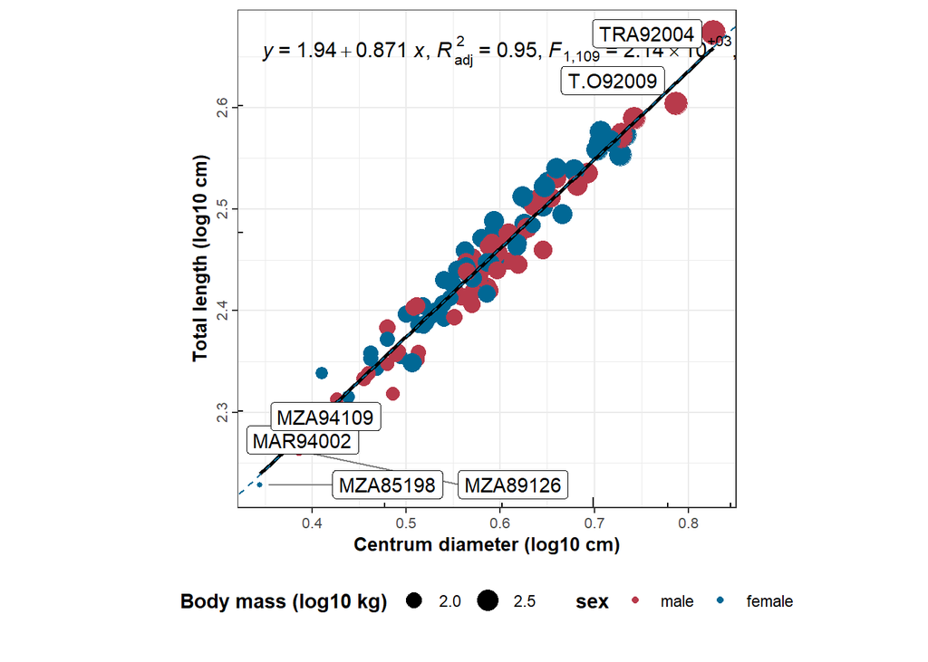

```r
# Plot.
carcharodon_carcharias_wintner |>
  ggplot(mapping = aes(x = log_cd,y = log_tl),group = sex, colour = sex, fill = sex) +
  annotation_logticks() +
  geom_point(aes(color = sex,size = log_netmass),
             shape = 19) +
  scale_color_manual(values = c("#B83A4B","#016895")) +
  scale_fill_manual(values =  c("#B83A4B","#016895")) +
  geom_smooth(method = "lm", se = FALSE, color = "black") +
  ggpmisc::stat_poly_eq(use_label(c("eq", "adj.R2", "f", "p", "n")),
                        size = 4.0,label.x = "left",label.y = "top",
                        color = "black") +
  # RLM line.
  geom_abline(slope = 0.8728,intercept = 1.9385,colour = "#016895",linetype = 2) +
  # Labels.
  labs(size = "Body mass (log10 kg)",x = "Centrum diameter (log10 cm)", y = "Total length (log10 cm)",
       colour = "sex",
       title = NULL,
       subtitle = NULL,
       caption = "") +
  geom_label_repel(aes(label = Tagno),
                  box.padding   = 0.35,
                  point.padding = 0.5,max.overlaps = 10,
                  segment.color = 'grey50') +
  theme_bw() +
  theme(axis.title = element_text(face = "bold",size = 10),
        axis.text = element_text(size = 8),
        axis.text.y = element_text(angle = 90,hjust = 0.5,vjust = 0.5),
        legend.position = "bottom",
        legend.title = element_text(face = "bold"),
        plot.title = element_text(face = "bold",size = 12),
        plot.subtitle = element_text(size = 10),
        aspect.ratio = 1)
```

### Regression diagnostics (TL)

```r
# Linear model assumption.
performance::check_normality(length_linear_fit_ols)
```

```
OK: residuals appear as normally distributed (p = 0.583).
```

Visual check of model assumptions (i.e. Linearity, Independence, Normality and Equal Variances).

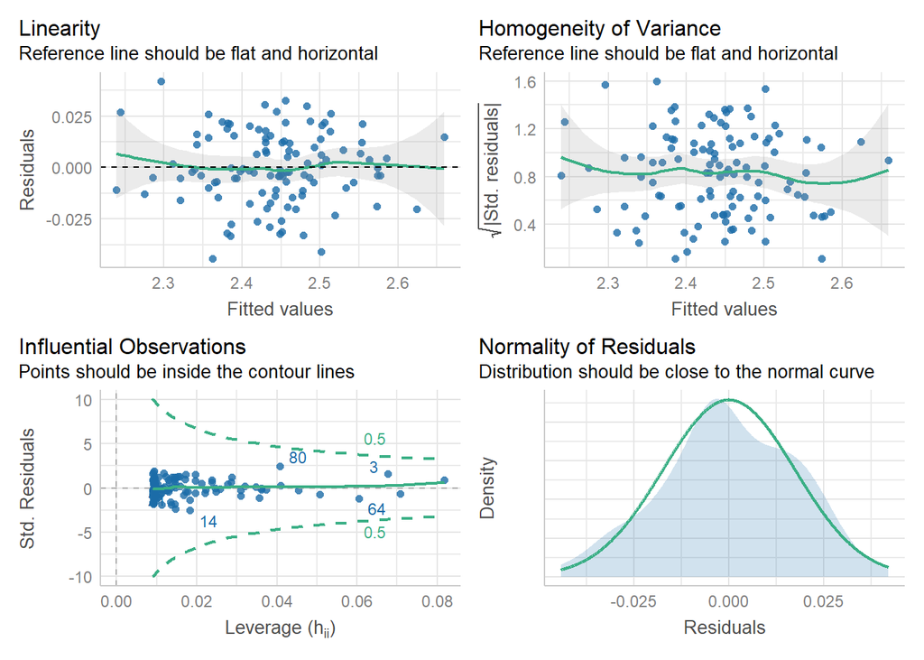

```r
performance::check_model(x = length_linear_fit_ols,
                         check = c("normality", "linearity","homogeneity", "outliers"),
                         axis_title_size = 8)
```

```r
# Assumptions checks.

# kable(nice_assumptions(model = length_linear_fit_ols), col.format.p = 2:4,
#       caption = "Diagnostics for the linear model (CD-TL) applied to C. carcharias.
#                  Diagnostic is how many assumptions (i.e. normality of residuals, homoscedasticity, and independence) are not respected by the model fit.
#                  P-values < .05 imply assumptions are not respected.") |>
#   kable_styling(bootstrap_options = "striped",full_width = T)
```

### Model fit II (BM)

```r
# Fit body mass linear model with OLS.
mass_linear_fit_ols <- lm(log_netmass ~ log_cd, data = carcharodon_carcharias_wintner)
# Summary.
mass_linear_fit_ols |>
  summary() |>
  broom::tidy(conf.int = TRUE)

# Accuracy.
broom::glance(mass_linear_fit_ols)

# RLM.
mass_linear_fit_rlm <- rlm(log_netmass~log_cd, data = carcharodon_carcharias_wintner)
# RSE.
summary(mass_linear_fit_rlm)$sigma

# Test if slope is equal to 3.
isomodel_02 <- smatr::slope.test(y = carcharodon_carcharias_wintner$log_netmass,
                                 x = carcharodon_carcharias_wintner$log_cd,
                                 test.value = 3,method = "OLS") # negative allometry.

# lrtest(mass_linear_fit_ols,mass_linear_fit_rlm)

# Mean Percentage Prediction Error (PPE).
ppe_02 <-
  ppe(true = 10^carcharodon_carcharias_wintner$log_netmass,
      pred = 10^as.vector(fitted(mass_linear_fit_ols)))
```

Relationship between the logarithm of centrum diameter and mass (A) and centrum diameter and mass on the measurement scale (B) in C. carcharias.

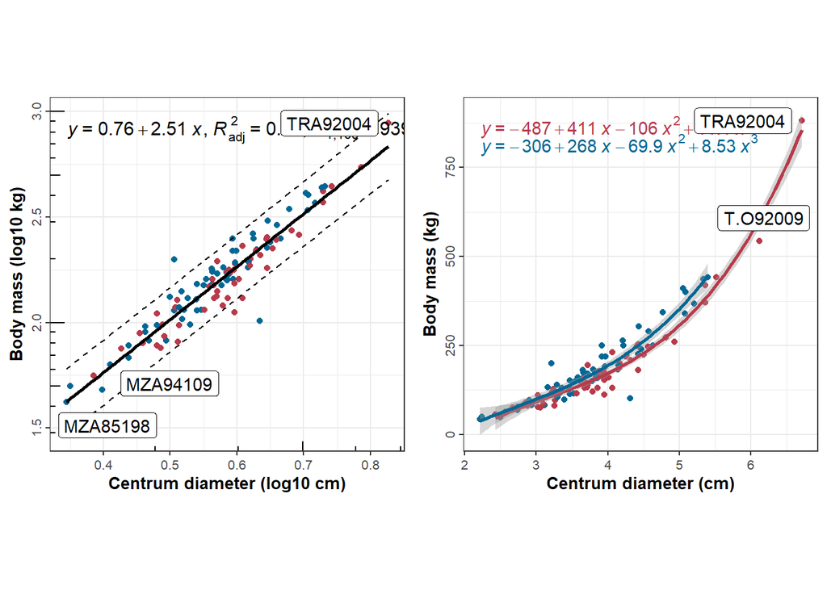

```r
# Prediction intervals.
piBM <-
  predict(object = mass_linear_fit_ols,newdata = data.frame(log_cd = carcharodon_carcharias_wintner$log_cd),interval = "prediction") |>
  as.data.frame()

ggarrange(
  # 1. CD vs Mass on log-scales.
  carcharodon_carcharias_wintner |>
  ggplot(mapping = aes(x = log_cd,y = log_netmass),group = sex, colour = sex, fill = sex) +
  annotation_logticks() +
  geom_point(aes(color = sex),shape = 19) +
  scale_color_manual(values = c("#B83A4B","#016895")) +
  scale_fill_manual(values =  c("#B83A4B","#016895")) +
  geom_smooth(method = "lm", se = FALSE, color = "black") +
  # Prediction intervals.
  geom_line(aes(y = piBM$lwr), col = "black", linetype = "dashed") +
  geom_line(aes(y = piBM$upr), col = "black", linetype = "dashed") +
  ggpmisc::stat_poly_eq(use_label(c("eq", "adj.R2", "f", "p", "n")),
                        size = 4.0,label.x = "left",label.y = "top",
                        color = "black") +
  # Labels.
  labs(x = "Centrum diameter (log10 cm)", y = "Body mass (log10 kg)",
       colour = "Sex") +
  geom_label_repel(aes(label = Tagno),
                  box.padding   = 0.35,
                  point.padding = 0.5,max.overlaps = 10,
                  segment.color = 'grey50') +
  theme_bw() +
  theme(axis.title = element_text(face = "bold",size = 10),
        axis.text = element_text(size = 8),
        axis.text.y = element_text(angle = 90,hjust = 0.5,vjust = 0.5),
        legend.position = "none",
        legend.title = element_text(face = "bold"),
        plot.title = element_text(face = "bold",size = 12),
        plot.subtitle = element_text(size = 10),
        aspect.ratio = 1),
  # 2. CD vs Mass on raw measurment scale.
  carcharodon_carcharias_wintner |>
  ggplot(mapping = aes(x = centrum_diameter_cm,y = netmass_kg),group = sex, colour = sex, fill = sex) +
  geom_point(aes(color = sex),shape = 19) +
  scale_color_manual(values = c("#B83A4B","#016895")) +
  scale_fill_manual(values =  c("#B83A4B","#016895")) +
  stat_poly_line(aes(colour = sex),formula = y ~ poly(x, 3, raw = TRUE)) +
  stat_poly_eq(aes(colour = sex, label = after_stat(eq.label)),formula = y ~ poly(x, 3, raw = TRUE)) +
  # Labels.
  labs(x = "Centrum diameter (cm)", y = "Body mass (kg)",colour = "Sex") +
  geom_label_repel(aes(label = Tagno),
                  box.padding   = 0.35,
                  point.padding = 0.5,max.overlaps = 10,
                  segment.color = 'grey50') +
  theme_bw() +
  theme(axis.title = element_text(face = "bold",size = 10),
        axis.text = element_text(size = 8),
        axis.text.y = element_text(angle = 90,hjust = 0.5,vjust = 0.5),
        legend.position = "none",
        legend.title = element_text(face = "bold"),
        plot.title = element_text(face = "bold",size = 12),
        plot.subtitle = element_text(size = 10),
        aspect.ratio = 1),
  # Add legend.
  common.legend = F,align = "hv")
```

### Leverage analysis (BM)

Here we explore the presence of unusual and influential observations in the BM model.

Regression diagnostics.

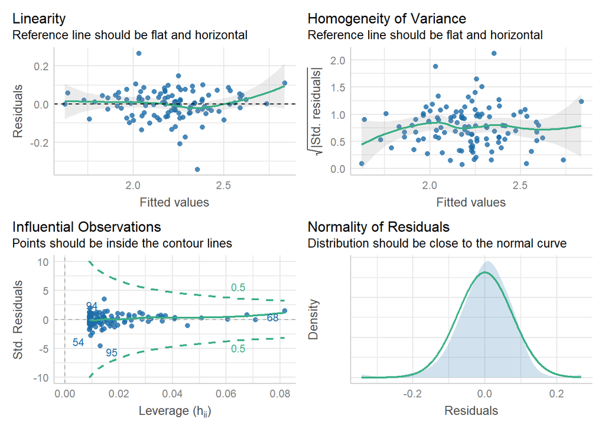

```r
# Regression diagnostics.
performance::check_normality(mass_linear_fit_ols)
performance::check_model(x = mass_linear_fit_ols,
                         check = c("normality", "linearity","homogeneity", "outliers"))
```

```r
# One assumption (i.e. normality) is not respected.

# kable(nice_assumptions(model = mass_linear_fit_ols), stars = T, col.format.p = 2:4) |>
#   kable_styling(bootstrap_options = "striped",
#                 full_width = T)
```

Leverage analysis. The size of the bubbles in the plot indicates the Cook’s D value of each data point.

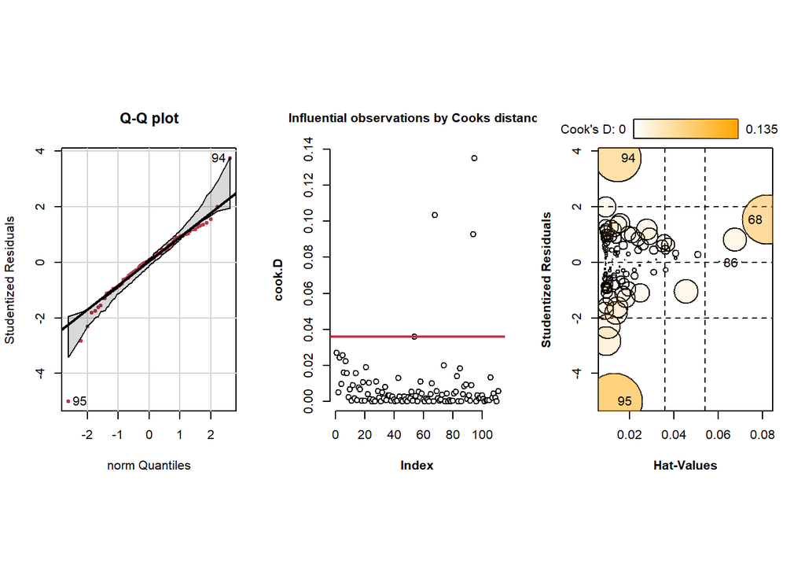

```r
cook.D <- cooks.distance(model = mass_linear_fit_ols)
# Plot.
layout(matrix(c(1,2,3), nrow = 1, ncol = 3,byrow = FALSE),
       respect = TRUE,widths = c(4,4,4),heights = c(6,6,6))
# Q-Q plot.
invisible(capture.output(
  car::qqPlot(mass_linear_fit_ols, main="Q-Q plot", distribution="norm",ylab = "Studentized Residuals",
              col = "#B83A4B",
              col.lines=carPalette()[1],
              pch = 19)
)
)

# Cooks distance.
plot(cook.D, pch=21, cex=1, main="Influential observations by Cooks distance",
     col = "black",bg = "white",font.lab = 2, cex.main = 1,bty = "n")

abline(h = 4/nrow(carcharodon_carcharias_wintner), col="#B83A4B",lwd = 2)
# Regression Influence Plot.
invisible(capture.output(car::influencePlot(model = mass_linear_fit_ols, fill.col=carPalette()[5],font.lab = 2)))
```

```r
# Model improvement.
mass_linear_fit_ols_2 <- lm(log_netmass ~ log_cd, data = carcharodon_carcharias_wintner[cook.D < 4/length(cook.D),])
#summary(mass_linear_fit_ols_2)

# Residual standard error (RSE) and R-squared.
c(summary(mass_linear_fit_ols)$sigm,summary(mass_linear_fit_ols_2)$sigma
) |> setNames(nm = c("Model I","Model II"))

c(summary(mass_linear_fit_ols)$r.squared,summary(mass_linear_fit_ols_2)$r.squared
) |> setNames(nm = c("Model I","Model II"))

# Check diagnostics.
# nice_table(nice_assumptions(model = mass_linear_fit_ols_2),stars = T, col.format.p = 2:4)

# Quadratic model (or second-degree polynomial).
mass_quad_fit_ols <- lm(log_netmass~log_cd+I(log_cd^2),data = carcharodon_carcharias_wintner,subset = cook.D < 4 / length(cook.D))
mass_quad_fit_ols |>
  summary()

# Model selection.
lrtest(mass_linear_fit_ols_2,mass_quad_fit_ols)  # No improvement.
AICc(mass_linear_fit_ols_2,mass_quad_fit_ols)

# Mean Percentage Prediction Error (PPE).
ppe_03 <-
  ppe(true = 10^carcharodon_carcharias_wintner[cook.D < 4/length(cook.D),]$log_netmass,
      pred = 10^as.vector(fitted(mass_linear_fit_ols_2)))
```

### Fossil Predictions (I)

#### Total length

In this section, **TL and BM** estimates are based on the white shark data from (Wintner and Cliff 1998). Point estimates, 95% prediction and confidence intervals are computed for each specimen.

Prediction are given by:

$$Y_i = \hat{\alpha} + \hat{\beta} \cdot X_i$$

**Specimen remarks**

P922-33: one side is cracked and artificially ‘swollen’ measuring 129 mm; the other un-deformed side is 125 mm. P922-32: 126 mm but inflated due to cracking. P9382: 118 mm. P922-37: 114 mm but most of the surface covered with nodules so measurement might be artificially inflated. P922-29: 117 mm as preserved but greatest radius is 63 mm which indicates an original 126 mm.

```r
# Fossil shark centrum diameter in centimeters.
aptian_shark <- data.frame(log_cd = log10(c(12.5,12.6,11.8,11.4,12.6)))
```

```r
# Total length (TL) estimates with 95% CI & PI.
pred_tl <-
  cbind(10^predict(object = length_linear_fit_ols,newdata = aptian_shark,interval = "prediction"),
        10^predict(object = length_linear_fit_ols,newdata = aptian_shark,interval = "confidence")[,2:3]) |>
  as.data.frame() |>
  unname() |>
  setNames(nm = c("fit",".pred_lower",".pred_upper",".conf_lower",".conf_upper")) |>
  # Add specimen and model information.
  mutate(specimen = c("NTM P 922-33","NTM P 922-32","NTM P 9382", "NTM P 922-37","NTM P 922-29"),
         source = rep("White shark data",5))

# Convert into long format.
long_format <-
  data.frame(fit = unlist(as.vector(pred_tl$fit)),
             xmin = c(pred_tl$.pred_lower,pred_tl$.conf_lower),
             xmax = c(pred_tl$.pred_upper,pred_tl$.conf_upper),
             intervals = c(rep("prediction",5),rep("confidence",5)),
             specimen = rep(c("NTM P 922-33","NTM P 922-32","NTM P 9382", "NTM P 922-37","NTM P 922-29"),2)) |>
  mutate(specimen = fct_relevel(specimen,c("NTM P 922-33","NTM P 922-32","NTM P 9382", "NTM P 922-37","NTM P 922-29")))

# Prediction plot.
tl_graph <-
  long_format |>
  ggplot(aes(y = specimen, x = fit, colour = intervals,linetype = intervals)) +
  scale_y_discrete(labels = pred_tl$specimen) +
  geom_errorbar(aes(xmin = xmin, xmax = xmax),
                width = 0.2,linewidth = 1.3,show.legend = T) +
  geom_point(size = 3,fill = "white",
             shape = 21,show.legend = F) +
  # Color intervals.
  scale_fill_manual(values =  c("#4D4D4D","#4D4D4D")) +
  scale_color_manual(values = c("#4D4D4D","#4D4D4D")) +
  # Average TL length
  geom_vline(aes(xintercept=mean(fit)),linetype=1,col = "#4D4D4D", lwd = 1.5) +
  # Largest documented extant great white shark (Carcharodon carcharias) (6.4 m) [Randall JE 1973].
  geom_vline(aes(xintercept = 640),linetype=1,col = "#B2182B", lwd = 1.5) +
  # Text
  annotate("text",x = 700, y = 3.8,
           label = "upper~size~limit~of~italic(C.~carcharias)",
           parse = TRUE,size = 1.5,
           col = "#B2182B",fontface = "bold") +
  # Curve.
  annotate(geom = "curve", x = 700, y = 3.9, xend = 645, yend = 3.8,
          curvature = .3, arrow = arrow(length = unit(2, "mm"))) +
  theme_minimal() +
  labs(x = "Total length (cm)",y = NULL) +
  theme(legend.position = "right",
        title = element_text(face = "bold"),
        plot.subtitle = element_text(face = "plain"),
        axis.text.y = element_text(face = "bold"))

# Apply the bias correction factor.
# pred_tl$fit * exp(summary(length_linear_fit_ols)$sigma^2/2) # corrected factor applied to predictions.

# intervals(xvar = pred_tl$fit)[c(1,7:8)]
```

#### Body mass

```r
# Fossil mass prediction.
pred_mass <-
  cbind(10^predict(object = mass_linear_fit_ols_2,newdata = aptian_shark,interval = "prediction"),
        10^predict(object = mass_linear_fit_ols_2,newdata = aptian_shark,interval = "confidence")[,2:3]) |>
  as.data.frame() |>
  unname() |>
  setNames(nm = c("fit",".pred_lower",".pred_upper",".conf_lower",".conf_upper")) |>
  # Add specimen and model information.
  mutate(specimen = c("NTM P 922-33","NTM P 922-32","NTM P 9382", "NTM P 922-37","NTM P 922-29"),
         source = rep("White shark data",5))

long_format_mass <-
  data.frame(fit = unlist(as.vector(pred_mass$fit)),
             xmin = c(pred_mass$.pred_lower,pred_mass$.conf_lower),
             xmax = c(pred_mass$.pred_upper,pred_mass$.conf_upper),
             intervals = c(rep("prediction",5),rep("confidence",5)),
             specimen = rep(c("NTM P 922-33","NTM P 922-32","NTM P 9382", "NTM P 922-37","NTM P 922-29"),2)) |>
  # slice(1:8) |>
  mutate(specimen = fct_relevel(specimen,c("NTM P 922-33","NTM P 922-32","NTM P 9382", "NTM P 922-37","NTM P 922-29")))

# Plot.
mass_graph <-
  long_format_mass |>
  ggplot(aes(y=specimen, x=fit, colour=intervals,linetype = intervals)) +
  scale_y_discrete(labels = pred_mass$specimen) +
  geom_errorbar(aes(xmin = xmin, xmax = xmax),
                width = 0.2,linewidth = 1.3,show.legend = T) +
  geom_point(size = 3,fill = "white", shape = 21,show.legend = F) +
  scale_fill_manual(values =  c("#4D4D4D","#4D4D4D")) +
  scale_color_manual(values = c("#4D4D4D","#4D4D4D")) +
  theme_minimal() +
  # Average BM
  geom_vline(aes(xintercept=mean(fit)),linetype=1,col = "#4D4D4D", lwd = 1.5) +
  # Maximum Great white shark body-weight: <https://www.fisheries.noaa.gov/species/white-shark>
  geom_vline(xintercept = 2041,lwd = 1.5, linetype=1, color = "#B2182B") +
  annotate("text", x = 2350, y = 3.2, label = "upper~size~limit~of~italic(C.~carcharias)",
           parse = TRUE,col = "#B2182B",size = 1.5) +
  labs(x = "Body mass (kg)",y = NULL) +
  theme(legend.position = "right",
        title = element_text(face = "bold"),
        plot.subtitle = element_text(face = "plain"),
        axis.text.y = element_text(face = "bold"))

# intervals(xvar = pred_mass$fit)[c(1,7:8)]
```

TL and BM estimates for the Darwin cardabiodontid vertebral centra.

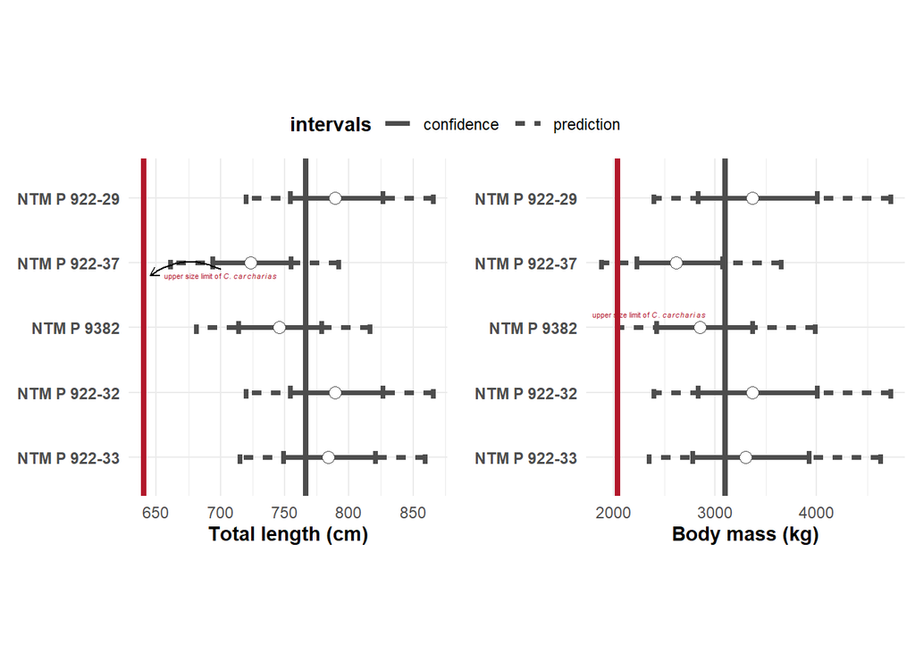

```r
# Combine length and mass predictions graphs.
ggarrange(tl_graph,mass_graph,common.legend = T) + theme(aspect.ratio = .5)
```

Log-space of C. carcharias centrum size vs the fossil specimens.

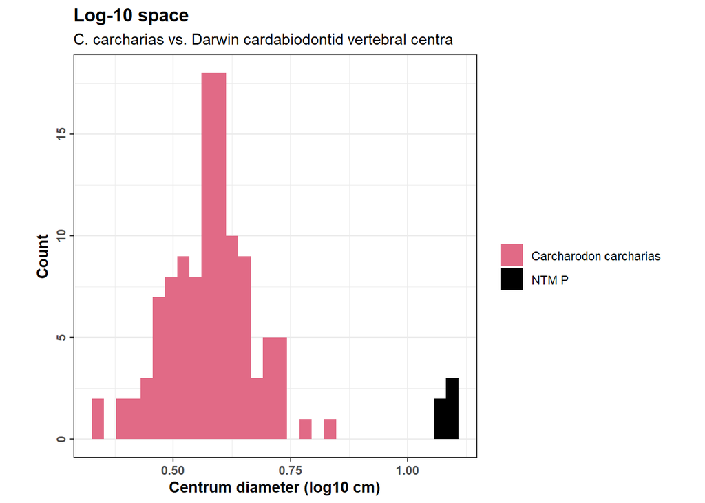

```r
bind_rows(
  carcharodon_carcharias_wintner |> select(log_cd,species),aptian_shark |> mutate(species = "NTM P")) |>
  ggplot(mapping = aes(x = log_cd, fill = species)) +
  geom_histogram(bins = 30) +
  scale_fill_manual(values = c("#E16A86","black")) +
  theme_bw() +
  theme(axis.text.x = element_text(face = "bold"),
        axis.text.y = element_text(face = "bold",angle = 90,hjust = 0.5,vjust = .5),
        axis.title.x = element_text(face = "bold"),
        axis.title.y = element_text(face = "bold"),
        legend.title = element_text(face = "bold"),
        title = element_text(face = "bold"),
        plot.subtitle = element_text(face = "plain"),
        aspect.ratio = 1) +
  labs(title = "Log-10 space",subtitle = "C. carcharias vs. Darwin cardabiodontid vertebral centra",
       x = "Centrum diameter (log10 cm)", y = "Count", fill = "")
```

```r
# Prepare data.
log_pred_tl <-
  cbind(predict(object = length_linear_fit_ols,newdata = aptian_shark,interval = "prediction"),
        predict(object = length_linear_fit_ols,newdata = aptian_shark,interval = "confidence")[,2:3]) |>
  as.data.frame() |>
  unname() |>
  setNames(nm = c("fit",".pred_lower",".pred_upper",".conf_lower",".conf_upper")) |>
  mutate(specimen = c("NTM P 922-33","NTM P 922-32","NTM P 9382", "NTM P 922-37","NTM P 922-29"))

# PI intervals.
PI <- predict(object = length_linear_fit_ols,
              newdata = data.frame(log_cd = carcharodon_carcharias_wintner$log_cd),
              interval = "prediction",se.fit = T,level = .95)

# Prediction interval data subset for plotting.
tl_intervals <-
  log_pred_tl |>
  mutate(log_cd = aptian_shark$log_cd)

p <-
  carcharodon_carcharias_wintner |>
  ggplot(aes(x = log_cd, y = log_tl)) +
  geom_point(fill = "white",size = 2, shape = 21) +
  geom_abline(intercept = 1.9393, slope = 0.8706,linewidth = 1,colour = "black") +
  annotation_logticks() +
  expand_limits(x = c(0.3443923,1.1003705), y = c(2.228113,2.937239)) +
  # Add bracketing lines.
  geom_vline(xintercept = 0.3443923,linetype = "dashed") +
  geom_vline(xintercept = 0.8267225,linetype = "dashed") +
  # Add prediction intervals.
  geom_line(aes(x = log_cd, y = PI$fit[,"lwr"]), color = "#E16A86") +
  geom_line(aes(x = log_cd, y = PI$fit[,"upr"]), color = "#E16A86") +
  # Add fossil predictions to base plot.
  geom_point(data = aptian_shark,mapping = aes(x = log_cd, y = log_pred_tl$fit), colour = "black", fill = "white",pch = 22, size = 2) +
  # Interpolation line.
  annotate(geom = "segment", x = 0.3443923, xend = 0.8267225, y = 2.8, yend = 2.8,
           colour = "darkgreen",arrow = arrow(type = "closed",length = unit(2, "mm"),ends = "both",angle = 20)) +
  # Extrapolation line.
  annotate(geom = "segment", x = 0.8267225, xend = 1.1003705, y = 2.3, yend = 2.3,
           colour = "darkgreen",arrow = arrow(type = "closed",length = unit(2, "mm"),ends = "both",angle = 20)) +
  labs(title = NULL,subtitle = NULL,
       y = "Total length (log10 cm)",
       x = "Centrum diameter (log10 cm)") +
  theme_bw() +
  theme(axis.title = element_text(face = "bold",size = 10),
        axis.text = element_text(size = 8),
        axis.text.y = element_text(angle = 90,hjust = 0.5,vjust = 0.5),
        legend.title = element_text(face = "bold"),
        legend.text = element_text(face = "italic"),
        plot.title = element_text(face = "bold",size = 12),
        plot.subtitle = element_text(size = 10),
        aspect.ratio = 1)

# Add error bars.
p0 <- p +
  geom_errorbar(data = tl_intervals, aes(x = log_cd,y = fit, ymin = .pred_lower,ymax = .pred_upper),
                width = 0.02,color = "black")
```

```r
# Prepare data.
log_pred_mass <-
  cbind(predict(object = mass_linear_fit_ols_2,newdata = aptian_shark,interval = "prediction"),
        predict(object = mass_linear_fit_ols_2,newdata = aptian_shark,interval = "confidence")[,2:3]) |>
  as.data.frame() |>
  unname() |>
  setNames(nm = c("fit",".pred_lower",".pred_upper",".conf_lower",".conf_upper"))
  # Raw-scale.
  # mutate(across(everything(), ~ 10^.)) |>
  # mutate(across(everything(), ~ round(.x,digits = 2)))

# PI intervals.
mPI <- predict(object = mass_linear_fit_ols_2,
               newdata = data.frame(log_cd = carcharodon_carcharias_wintner[cook.D < 4/length(cook.D),]$log_cd),
               interval = "prediction",se.fit = T,level = .95)

# Prediction interval data subset for plotting.
mass_intervals <-
  log_pred_mass |>
  mutate(log_cd = aptian_shark$log_cd)

p1 <-
  carcharodon_carcharias_wintner |>
  filter(cook.D < 4 / n()) |>
  ggplot(aes(x = log_cd, y = log_netmass)) +
  geom_point(fill = "white",size = 2, shape = 21) +
  geom_abline(intercept = 0.7598, slope = 2.5089,linewidth = 1,colour = "black") +
  annotation_logticks() +
  expand_limits(x = c(0.3443923,1.1003705), y = c(1.623249, 3.674706)) +
  # Add bracketing lines.
  geom_vline(xintercept = 0.3443923,linetype = "dashed") +
  geom_vline(xintercept = 0.7867514,linetype = "dashed") +
  # Add prediction intervals.
  geom_line(aes(x = log_cd, y = mPI$fit[,"lwr"]), color = "#E16A86") +
  geom_line(aes(x = log_cd, y = mPI$fit[,"upr"]), color = "#E16A86") +
  # Add fossil predictions to base plot.
  geom_point(data = aptian_shark,mapping = aes(x = log_cd, y = log_pred_mass$fit), colour = "black", fill = "white",pch = 22, size = 2) +
  # Interpolation line.
  annotate(geom = "segment", x = 0.3443923, xend = 0.7867514, y = 3.0, yend = 3.0,
           colour = "darkgreen",arrow = arrow(type = "closed",length = unit(2, "mm"),ends = "both",angle = 20)) +
  # Extrapolation line.
  annotate(geom = "segment", x = 0.7867514, xend = 1.1003705, y = 2.0, yend = 2.0,
           colour = "darkgreen",arrow = arrow(type = "closed",length = unit(2, "mm"),ends = "both",angle = 20)) +
  labs(title = NULL,subtitle = NULL,
       y = "Body mass (log10 kg)",
       x = "Centrum diameter (log10 cm)") +
  theme_bw() +
  theme(axis.title = element_text(face = "bold",size = 10),
        axis.text = element_text(size = 8),
        axis.text.y = element_text(angle = 90,hjust = 0.5,vjust = 0.5),
        legend.title = element_text(face = "bold"),
        legend.text = element_text(face = "italic"),
        plot.title = element_text(face = "bold",size = 12),
        plot.subtitle = element_text(size = 10),
        aspect.ratio = 1)

# Add error bars.
p01 <- p1 +
  geom_errorbar(data = mass_intervals, aes(x = log_cd,y = fit, ymin = .pred_lower,ymax = .pred_upper),
                width = 0.02,color = "black")
```

### Model fit III (TL)

#### Species-level analysis

We combine all lamniform species data into one master dataframe (N=1912). *O. ferox* and *O. noronhai* are not considered because of low sample size. A series of species-level OLS models are built and fitted. Slope and intercept values are subsequently compared.

```r
# Function.
fit_regression <- function(x) {
  lm(log_tl ~ log_cd, x)
}

# Fit linear models.
slope_intercept <-
  lamniformes_data |>
  group_by(species) |>
  do(model = fit_regression(.)) |>
  tibble() |>
  mutate("β0" = map_dbl(model, ~ coef(.)["(Intercept)"]),
         "β1" = map_dbl(model, ~ coef(.)["log_cd"])) |>
  mutate("y" = paste(round(β0,digits = 2),"+", round(β1,digits = 2),"x")) |>
  mutate(round(map_df(model, ~ glance(.)[1]),digits = 2)) |>
  mutate(map_df(model, ~ glance(.)[12])) |>
  mutate(map_df(model, ~ tidy(.,conf.int = TRUE)["p.value"][2,])) |>
  mutate(map_df(model, ~ tidy(.,conf.int = TRUE)["conf.low"][2,])) |>
  mutate(map_df(model, ~ tidy(.,conf.int = TRUE)["conf.high"][2,])) |>
  mutate("MAE" = round(map_dbl(model, ~ mean(abs(residuals(.)))),digits = 2)) |>
  # select(-model) |>
  rename("N" = "nobs")

# Pearson correlations.
lamn_corr <-
  lamniformes_data  |>
  group_by(species) |>
  summarize(correlation = cor(log_cd,log_tl, method = "pearson"))

# Pearson correlations on the log-10 values: Entire dataset.
cor(x = lamniformes_data$log_tl,y = lamniformes_data$log_cd) # cor = 0.79 (no different from the raw values: cor = 0.74)
```

```
[1] 0.7923337
```

Bivariate visualizations (log-scale) showing the relationship between CD-TL in lamniform species.

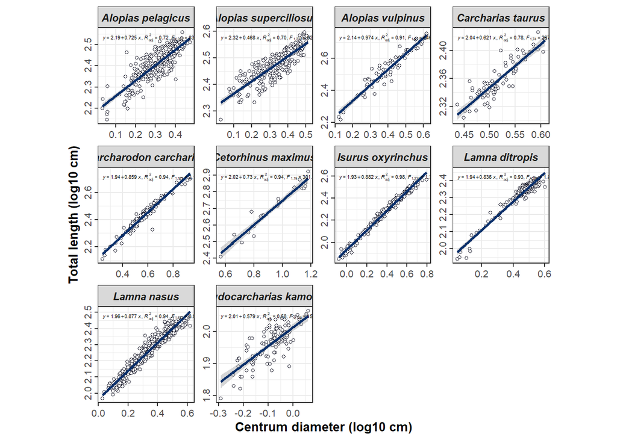

```r
# Color vector.
col_vec <- c("#264653", "#2A9D8F", "#E9C46A", "#F4A261", "#E76F51",
             "#457B9D", "#1D3557", "#F0A8C0FF", "#6D6875", "#A8DADC")

# CD-TL relationship in lamniform species.
intraspecific_graph <- lamniformes_data |>
  mutate(ecology = case_when(species == "Cetorhinus maximus" ~ "Microphagous", TRUE ~ "Macrophagous")) |>
  ggplot(aes(x = log_cd, y = log_tl)) +
  scale_fill_manual(values =  col_vec) +
  scale_color_manual(values = col_vec) +
  labs(title = NULL,subtitle = NULL,
       y = "Total length (log10 cm)",
       x = "Centrum diameter (log10 cm)", colour = "Species") +
  annotation_logticks() +
  geom_smooth(aes(colour = species),method = "lm",se = F) +
  geom_point(aes(color = species), fill = "white",size = 2, shape = 21) +
  theme_bw() +
  theme(axis.title = element_text(face = "bold",size = 10),
        axis.text = element_text(size = 8),
        axis.text.y = element_text(angle = 90,hjust = 0.5,vjust = 0.5),
        legend.position = "none",
        legend.title = element_text(face = "bold"),
        legend.text = element_text(face = "italic"),
        plot.title = element_text(face = "bold",size = 12),
        plot.subtitle = element_text(size = 10),
        aspect.ratio = 1)

# Slopes only.
estimated_slopes <- lamniformes_data |>
  group_by(species) |>
  do(tidy(lm(log_tl ~ log_cd, data = .),conf.int = T)) |>
  dplyr::select(species,term,estimate,contains("conf")) |>
  rename("Estimate" = "estimate") |>
  filter(term != "(Intercept)") |>
  ggplot(mapping = aes(x = fct_rev(species), y = Estimate)) +
  geom_errorbar(aes(ymin = conf.low, ymax = conf.high),
                color = col_vec,
                position = position_dodge(0.4), width = .3,show.legend = F) +
  geom_point(aes(color = species),shape = 21,fill = "white",show.legend = F) +
  geom_hline(yintercept = c(1), linetype = "dashed") +
  scale_fill_manual(values = col_vec) +
  scale_color_manual(values = col_vec) +
  labs(x = NULL) +
  coord_flip() +
  theme_bw() +
  theme(aspect.ratio = 1,
        panel.grid.major.y = element_blank(),
        axis.text.y = element_blank())

# Alternative graph.
lamniformes_data |>
  dplyr::select(species, log_cd,log_tl) |>
  ggplot(aes(x = log_cd, y = log_tl)) +
  geom_point(size = 1, shape = 21, fill = "white", colour = "#2A2B3AFF") +
  geom_smooth(method = "lm",col = "#08306b") +
  ggpmisc::stat_poly_eq(use_label(c("eq", "adj.R2", "f", "p")),
                        size = 1.5,label.x = "left",label.y = "top",
                        color = "black") +
  labs(x = "Centrum diameter (log10 cm)", y = "Total length (log10 cm)") +
  facet_wrap(.~species, scales = "free",ncol = 4,nrow = 4) +
  theme_bw() +
  theme(axis.title = element_text(face = "bold",size = 10),
        axis.text = element_text(size = 8),
        axis.text.y = element_text(angle = 90,hjust = 0.5,vjust = 0.5),
        legend.position = "none",
        legend.title = element_text(face = "bold"),
        legend.text = element_text(face = "italic"),
        plot.title = element_text(face = "bold",size = 12),
        plot.subtitle = element_text(size = 10),
        strip.text = element_text(face = "bold.italic"),
        aspect.ratio = 1)
```

```r
dist_species <-
  lamniformes_data |>
  select(log_tl,log_cd, species) |>
  pivot_longer(cols = c("log_tl","log_cd"),values_to = "value",names_to = "var") |>
  ggplot(aes(x = value, y = species)) +
  stat_slab(aes(y = fct_rev(species), fill = species),height = 2, color = "white") +
  scale_fill_manual(values =  col_vec) +
  scale_color_manual(values = col_vec) +
  labs(x = "Centrum diameter (log10 cm)",
       y = NULL) +
  theme_bw() +
  theme(panel.grid.major.y = element_blank(),
        axis.title = element_text(face = "bold",size = 10),
        axis.text = element_text(size = 8),
        axis.ticks.y = element_blank(),
        axis.text.y = element_text(face = "italic"),
        legend.position = "none",
        legend.title = element_text(face = "bold"),
        legend.text = element_text(face = "italic"),
        plot.title = element_text(face = "bold",size = 12),
        plot.subtitle = element_text(size = 10),
        aspect.ratio = 1) +
  facet_wrap(.~var,scales = "free_x")
```

#### Heterogeneous slopes test

```r
# Homogeneity of slopes test (additive model).
common_slope <- lm.rrpp(log_tl ~ log_cd + species, SS.type = "III",RRPP = T,iter = 999,data = lamniformes_data)
# Heterogeneity of slopes test (interaction model)
unqiue_slope <- lm.rrpp(log_tl ~ log_cd * species, SS.type = "III",RRPP = T,iter = 999,data = lamniformes_data)

# summary(common_slope)$table # null
# summary(unqiue_slope)$table # alternative

# Which model is better?
# anova(common_slope,unqiue_slope,print.progress = F)$table
model.comparison(common_slope,unqiue_slope,type = "logLik")$table |>
  kable() |>
  kable_styling()
```

|  | logLik | residual.pc.no | penalty | AIC |
| --- | --- | --- | --- | --- |
| log_cd + species | 3741.650 | 1 | 24 | -7459.300 |
| log_cd + species + log_cd:species | 3967.132 | 1 | 42 | -7892.264 |

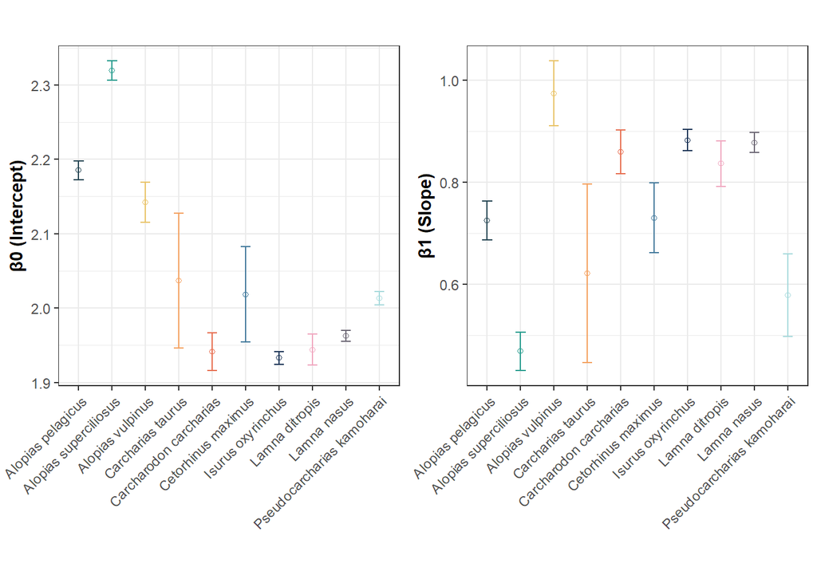

```r
# To work with emmeans.
unqiue_slope_em <- lm(log_tl ~ log_cd * species, data = lamniformes_data) # heterogeneity of slopes test (iteraction model)

# Intercepts (predicted values of a when b = 0)
ggarrange(
  emmeans::emmeans(object = unqiue_slope_em, ~ species, at = list(log_cd = 0)) |>
  as.data.frame() |>
  suppressMessages() |>
  ggplot(mapping = aes(x = species,y = emmean, fill = species, colour = species)) +
  geom_point(fill = "white", shape = 21) +
  geom_errorbar(aes(ymin = lower.CL, ymax = upper.CL),color = col_vec,
                position = position_dodge(0.4), width = .3) +
  scale_fill_manual(values = col_vec) +
  scale_color_manual(values = col_vec) +
  labs(x = NULL, y = "β0 (Intercept)") +
  theme_bw() +
  theme(axis.text.x = element_text(angle = 45,hjust = 1,vjust = 1),
        axis.title = element_text(face = "bold"),
        aspect.ratio = 1),
  # Slopes.
  emmeans::emtrends(unqiue_slope_em, specs = "species", var = "log_cd") |>
  as.data.frame() |>
  ggplot(mapping = aes(x = species,y = log_cd.trend, fill = species, colour = species)) +
  geom_point(fill = "white", shape = 21) +
  geom_errorbar(aes(ymin = lower.CL, ymax = upper.CL),color = col_vec,
                position = position_dodge(0.4), width = .3) +
  scale_fill_manual(values = col_vec) +
  scale_color_manual(values = col_vec) +
  labs(x = NULL, y = "β1 (Slope)") +
  theme_bw() +
  theme(axis.text.x = element_text(angle = 45,hjust = 1,vjust = 1),
        axis.title = element_text(face = "bold"),
        aspect.ratio = 1),
  # Common legend.
  common.legend = T,legend = "none",label.x = NULL
)
```

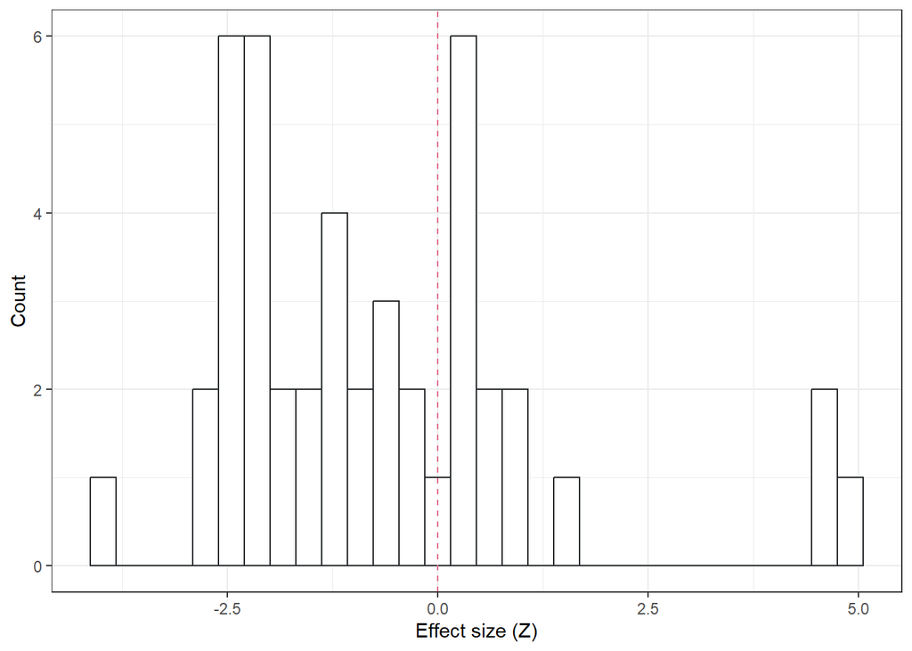

```r
# Compare slopes.
PW <- pairwise(unqiue_slope, groups = lamniformes_data$species, covariate = NULL)

# Select the ones that are significant.
summary(PW, test.type = "dist", confidence = 0.95, stat.table = TRUE)$summary.table  |>
  as.data.frame() |>
  # mutate("`Pr > d`" = p.adjust(p = `Pr > d`,method = "fdr"))
  # filter(`Pr > d` <= 0.05) |>
  mutate(across(1:4, ~ round(.x, digits = 3))) |>
  # filter(Z >= 0)
  # Look at the distribution of effect sizes.
  ggplot(aes(x = Z)) +
  geom_histogram(col = "#25282AFF", fill = "white") +
  geom_vline(xintercept = 0, linetype = 2, col = "#E16A86") +
  labs(x = "Effect size (Z)", y = "Count") +
  theme_bw()
```

```r
  # knitr::kable(caption = "Pairwise statistics from an analysis of covariance. The dist-test compares LS means
  #                       (estimated response at mean log-CD) among species.") |>
  #kable_styling()
```